# Insert chapter 2 title here

## 3 Fitting the model

First I printed the correlation matrix again, and decided to choose the following variables to the model:

y (dependent) = Points x (explanatory) = Attitude, deep, surf

The first model (fit) indicated that only the attitude (***) was statistically significant explanatory variable. Next I removed the deep and surf, and entered gender and stra (fit1). Still the attitude is the only one that is significant, so I will continue with the model fit2: Points (y)~Attitude (x).

```r
#the correlations in a separate df here as a reminder
correlations <- round(cor(learning2014_3[,c(2:7)]), 2)
correlations
```

```
##            Age Attitude  deep  stra  surf Points
## Age       1.00     0.02  0.03 -0.14 -0.14  -0.09
## Attitude  0.02     1.00  0.11 -0.18 -0.18   0.44
## deep      0.03     0.11  1.00 -0.32 -0.32  -0.01
## stra     -0.14    -0.18 -0.32  1.00  1.00  -0.14
## surf     -0.14    -0.18 -0.32  1.00  1.00  -0.14
## Points   -0.09     0.44 -0.01 -0.14 -0.14   1.00
```

```r
fit <- lm(Points ~ Attitude + deep + surf, data = learning2014_3)
summary(fit)
```

```
##
## Call:
## lm(formula = Points ~ Attitude + deep + surf, data = learning2014_3)
##
## Residuals:
##      Min       1Q   Median       3Q      Max
## -16.9168  -3.1487   0.3667   3.8326  11.3519
##
## Coefficients:
##             Estimate Std. Error t value Pr(>|t|)
## (Intercept) 18.35507    4.71237   3.895 0.000143 ***
## Attitude     0.34661    0.05766   6.011 1.18e-08 ***
## deep        -0.94846    0.79025  -1.200 0.231815
## surf        -1.09114    0.83599  -1.305 0.193669
## ---
## Signif. codes:  0 '***' 0.001 '**' 0.01 '*' 0.05 '.' 0.1 ' ' 1
##
## Residual standard error: 5.313 on 162 degrees of freedom
## Multiple R-squared:  0.2024, Adjusted R-squared:  0.1876
## F-statistic:  13.7 on 3 and 162 DF,  p-value: 5.217e-08
```

```r
#Entered the gender and stra as x.

fit1 <- lm(Points ~ Attitude + gender + stra, data = learning2014_3)
summary(fit1)
```

```
##
## Call:
## lm(formula = Points ~ Attitude + gender + stra, data = learning2014_3)
##
## Residuals:
##      Min       1Q   Median       3Q      Max
## -17.0594  -3.2139   0.5462   3.9774  10.5871
##
## Coefficients:
##             Estimate Std. Error t value Pr(>|t|)
## (Intercept) 14.07420    3.13432   4.490 1.34e-05 ***
## Attitude     0.35265    0.06017   5.861 2.51e-08 ***
## genderM     -0.54387    0.91760  -0.593    0.554
## stra        -0.80968    0.79883  -1.014    0.312
## ---
## Signif. codes:  0 '***' 0.001 '**' 0.01 '*' 0.05 '.' 0.1 ' ' 1
##
## Residual standard error: 5.331 on 162 degrees of freedom
## Multiple R-squared:  0.197,  Adjusted R-squared:  0.1822
## F-statistic: 13.25 on 3 and 162 DF,  p-value: 8.854e-08
```

```r
#Left the Attitude as x.

fit2 <- lm(Points ~ Attitude, data = learning2014_3)
summary(fit2)
```

```
##
## Call:
## lm(formula = Points ~ Attitude, data = learning2014_3)
##
## Residuals:
##      Min       1Q   Median       3Q      Max
## -16.9763  -3.2119   0.4339   4.1534  10.6645
##
## Coefficients:
##             Estimate Std. Error t value Pr(>|t|)
## (Intercept) 11.63715    1.83035   6.358 1.95e-09 ***
## Attitude     0.35255    0.05674   6.214 4.12e-09 ***
## ---
## Signif. codes:  0 '***' 0.001 '**' 0.01 '*' 0.05 '.' 0.1 ' ' 1
##
## Residual standard error: 5.32 on 164 degrees of freedom
## Multiple R-squared:  0.1906, Adjusted R-squared:  0.1856
## F-statistic: 38.61 on 1 and 164 DF,  p-value: 4.119e-09
```

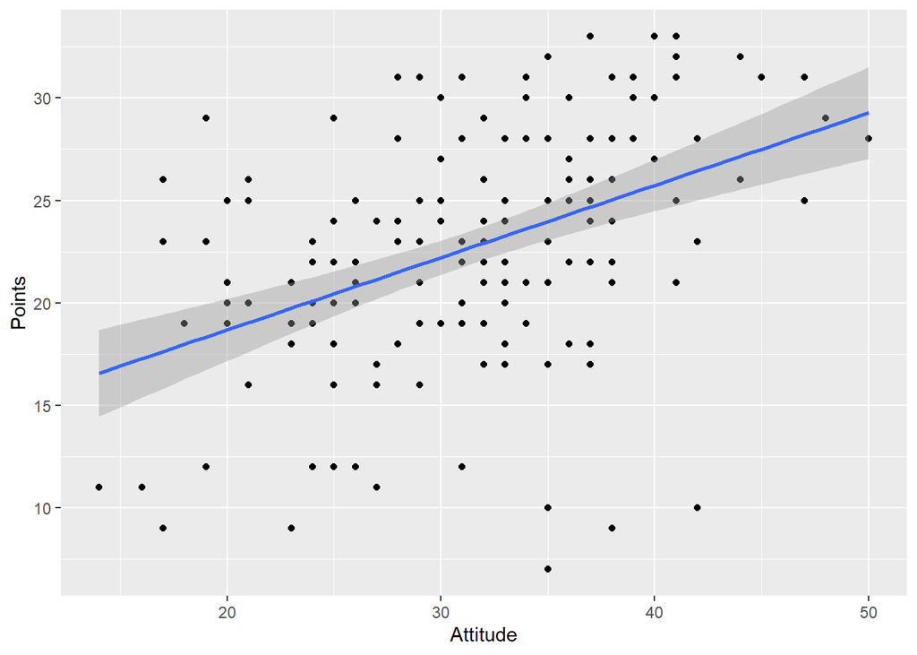

```r
qplot(Attitude, Points, data = learning2014_3) + geom_smooth(method = "lm")
```